# Introduction to Markov Chains for MCMC

## Introduction

A (discrete) **Markov chain** is a random (stochastic) process \({X_t : t \in T}\) that can take *k*-states over time \(t = 1, 2, ...\). The process starts at one of these states \((i)\) and proceeds forward to another state \((j)\) with some probability \(p_{i,j}\), the probability of transitioning from state *i* to state *j*. The probabilities \(p_{i,j}\) are called *transition probabilities*.

\[ P_{m,n} = \begin{pmatrix} p_{1,1} & p_{1,2} & \cdots & p_{1,n} \\ p_{2,1} & p_{2,2} & \cdots & p_{2,n} \\ \vdots & \vdots & \ddots & \vdots \\ p_{m,1} & p_{m,2} & \cdots & p_{m,n} \end{pmatrix} \]

## Two-State Markov Chain

Consider an ordered stochastic process with *k* = 2 states (or outcomes), *[0, 1]*. This chain takes \(X_1, X_2, ...\) steps where at each step it transitions between the two states with some probability \(p_{i,j}\). When the chain is at state \(i = 0\), the chain can transition to state \(j = 1\) with some probability, \(p_{0,1} = \alpha\), or remain at \(j = 0\) with probability \(p_{0,0} = 1 - \alpha\).

Likewise, if the chain is currently at state \(i = 1\), the chain can transition to \(j = 0\) with probability \(p_{1,0} = \beta\) or remain at \(j = 1\) with probability \(p_{1,1} = 1 - \beta\).

## Two-State Markov Chain

In a Markov chain, the random variables \(X_t\) depend on the previous it state \(X_{t-1}\). Thus, the random variables are not independent; autocorrelation exists. The random variables, albeit dependent, are only dependent on the previous iteration such that the transition probabilities only depend on the most recent state \[ P(X_t = x_{t} | X_{t-1} = x_{t-1}, X_{t-2} = x_{t-2}, ...) = P(X_t = x_t | X_{t-1} = x_{t-1}) \]

This conditional dependence on one-previous-step is known as the **Markov Property**.

## Two-State Markov Chain

From the conditional probabilities, we can form a **transition matrix**

\[ \displaystyle \mathbf{P}_{2 \times 2} = \begin{array} _ & 0 & 1 \\ 0 & p_{i,i} & p_{i,j} \\ 1 & p_{j,j} & p_{j,j} \end{array} \ = \begin{array} _ & 0 & 1 \\ 0 & p_{0,0} & p_{0,1} \\ 1 & p_{1,0} & p_{1,1} \end{array} \]

where the \(i^{th}\) row gives the conditional distribution of \(X_t | X_{t-1}\), and each row's probabilities sum up to 1.

## Example: 2-State Markov Chain

\[ \mathbf{P}_{2 \times 2} = \begin{pmatrix} p_{0,0} & p_{0,1} \\ p_{1,0} & p_{1,1} \end{pmatrix} \ = \begin{pmatrix} 0.6 & 0.4 \\ 0.55 & 0.45 \end{pmatrix} \]

## Example: 2-State Markov Chain

```r
m = 2000;
n = 1:m;

x = numeric(m);

x[1] = 0

alpha = 0.4;
beta = 0.55
# Simulation
for (i in 2:m){
    if (x[i-1]==0){
        x[i] = rbinom(1, 1, alpha)
    } else {
        x[i] = rbinom(1, 1, 1 - beta)
    }
}
```

## Example: 2-State Markov Chain

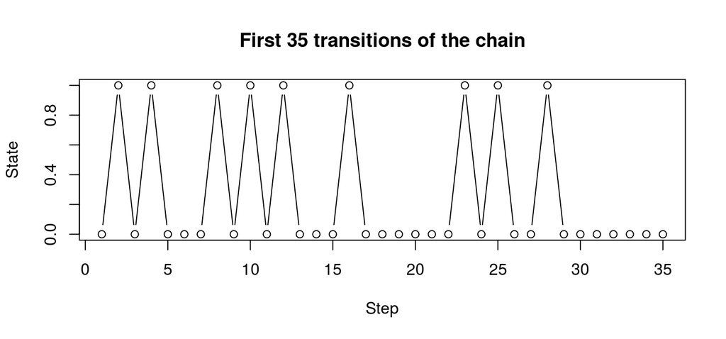

```r
## First 35 transitions of the chain
plot(x[1:35], type="b",
     main = "First 35 transitions of the chain",
     xlab="Step", ylab="State")
```

As can be seen in the first \(t = 1, ..., 35\) transitions of the chain, the Markov chain does not always leave its current state. It transitions with a given transition probability.

## Another Example: 3-state Markov chain

For this following example we'll be utilizing the `markovchain` library available from **CRAN**. Revolution Analytics (now an extension of Microsoft) has a nice blog post and tutorial on the use of this package. See [*Getting Started with Markov Chains*](http://blog.revolutionanalytics.com/2016/01/getting-started-with-markov-chains.html)

Consider a basketball team currently participating in a tournament. As they proceed through their games, assume the team has three states: *win, lose, tie*. Say, at the start of the season, they win their first game, \(X_0 = win\). From this point, they have probabilities of winning, losing or drawing their next game.

For our favorite team, say these probabilities are \(P(X_t = win | X_{t-1} = win) = 0.35\), \(P(X_t = lose | X_{t-1} = win) = 0.45\), \(P(X_t = tie | X_{t-1} = win) = 0.2\).

However, if they were to lose their first game, the probabilities change to \(P(X_t = win | X_{t-1} = lose) = 0.60\), \(P(X_t = lose | X_{t-1} = lose) = 0.30\), \(P(X_t = tie | X_{t-1} = lose) = 0.1\).

And if they were to tie their first game, then \(P(X_t = win | X_{t-1} = tie) = 0.55\), \(P(X_t = lose | X_{t-1} = tie) = 0.40\), \(P(X_t = tie | X_{t-1} = tie) = 0.05\). Thus, these probabilities construct a transition matrix **P**.

## Another Example: 3-state Markov chain

\[ P_{3 \times 3} = \begin{pmatrix} p_{win,win} & p_{win,lose} & p_{win,tie} \\ p_{lose,win} & p_{lose,lose} & p_{lose,tie} \\ p_{draw,win} & p_{tie,lose} & p_{tie,tie} \\ \end{pmatrix} \ = \begin{pmatrix} 0.35 & 0.45 & 0.20 \\ 0.60 & 0.30 & 0.10 \\ 0.55 & 0.40 & 0.05 \\ \end{pmatrix} \]

## Another Example: 3-state Markov chain

```r
library(markovchain)
## set up transition matrix
P <- matrix(data = c(0.35, 0.45, 0.20,
                     0.60, 0.30, 0.10,
                     0.55, 0.40, 0.05), byrow = TRUE,
            nrow = 3, ncol = 3,
            dimnames = list(c("win", "lose", "tie"), c("win", "lose", "tie")))

P <- new( "markovchain", transitionMatrix = P)
```

## Another Example: 3-state Markov chain

```
##       win lose  tie
## win  0.35 0.45 0.20
## lose 0.60 0.30 0.10
## tie  0.55 0.40 0.05
```

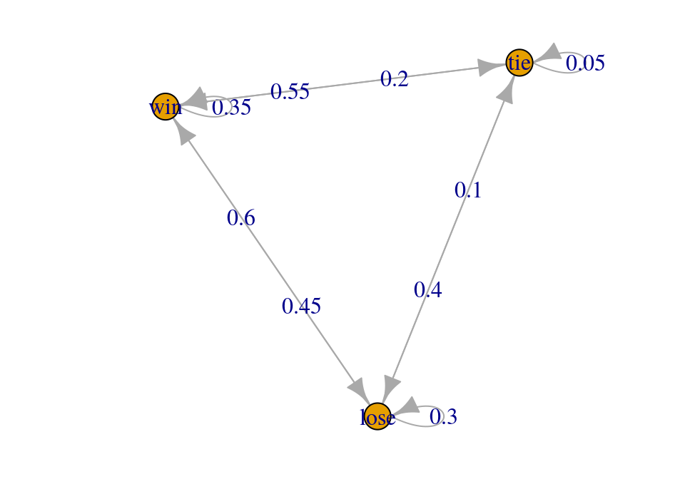

## Limiting Probabilities

The *Chapman-Kolmogorov* equations provide a method for computing 1, 2, …, *n*-step transition probabilities. The following can be used to calculate the *n*-step probabilities

\[ \displaystyle P^{n+m}_{ij} = \sum_{x=0}^{\infty} P^{n}_{ix} P^{m}_{xj} \text{ for all }\ n,m \geq 0,\ \text{all}\ i,j \] Let \(\mathbf{P}^{(n)}\) denote the *n*-ste transition matrix, then by the *Chapman-Kolmogorov* equations

\[ \mathbf{P}^{(n+m)} = \mathbf{P}^{(n)} \cdot \mathbf{P}^{(m)} \]

Thus, we can use simple matrix multiplication to evaluate the probability matrix for step *n*.

## Limiting Probabilities

```r
P <- matrix(data = c(0.35, 0.45, 0.20,
                     0.60, 0.30, 0.10,
                     0.55, 0.40, 0.05), byrow = TRUE,
            nrow = 3, ncol = 3,
            dimnames = list(c("win", "lose", "tie"), c("win", "lose", "tie")))

print(P) ## initial probabilities
```

```
##       win lose  tie
## win  0.35 0.45 0.20
## lose 0.60 0.30 0.10
## tie  0.55 0.40 0.05
```

```r
P_2 = P %*% P
print(P_2)
```

```
##         win   lose    tie
## win  0.5025 0.3725 0.1250
## lose 0.4450 0.4000 0.1550
## tie  0.4600 0.3875 0.1525
```

## Limiting Probabilities

```r
P_4 = P_2 %*% P_2
print(P_4)
```

```
##            win      lose       tie
## win  0.4757688 0.3846188 0.1396125
## lose 0.4729125 0.3858250 0.1412625
## tie  0.4737375 0.3854438 0.1408188
```

```r
P_8 = P_4 %*% P_4
print(P_8)
```

```
##            win      lose       tie
## win  0.4743866 0.3851979 0.1404155
## lose 0.4743798 0.3852007 0.1404195
## tie  0.4743818 0.3851999 0.1404183
```

```r
P_16 = P_8 %*% P_8
print(P_16)
```

```
##            win      lose       tie
## win  0.4743833 0.3851992 0.1404175
## lose 0.4743833 0.3851992 0.1404175
## tie  0.4743833 0.3851992 0.1404175
```

```r
P_20 = P_16 %*% P_4
print(P_20)
```

```
##            win      lose       tie
## win  0.4743833 0.3851992 0.1404175
## lose 0.4743833 0.3851992 0.1404175
## tie  0.4743833 0.3851992 0.1404175
```

## Limiting Probabilities

By step 20, it appears that we see a convergence in the *n*-step transition matrix. We've arrived at a limiting distribution for our 3-state Markov chain.

Not all Markov chains have limiting distributions, especially is there is not free movement across all states.

For a more thorough review of Markov chains, see [*Chapter 11: Markov Chains*](http://www.dartmouth.edu/~chance/teaching_aids/books_articles/probability_book/Chapter11.pdf).

## Ergodic Properties

For MCMC computations, only Markov chains with specific properties can be used. Markov chains are constructed from a *transition kernel K*, a conditional probability density such that \(X_{t+1} \sim K(X_t, X_{t+1})\).

As we continue with notes and definitions, note that this will be through the perspective of a discrete-time stochastic processes, \((X_t)_{t \in \mathbb{N}}\)

## Ergodic Properties

The chains encountered in MCMC settings enjoy a very strong stability property, a *stationary probability distribution*. A stationary probability distribution exists if the kernel *K* allows for free movement all over the state space for all \(X_1, X_2, ..., X_t\) transitions. This freedom to move all around the state space is called *irreducibility*, and is essential for MCMC algorithms. Irreducibility states that for \(n \in \mathbb{N}\) such that \(P(X_n \in A | X_0) > 0\) for every *A* such that \(\pi(A) > 0\).

The irreducibility property also ensures that most of the chains involved in MCMC algorithms are *recurrent*, that the number of times a chain visits an arbitrary set *A* in the state space is infinity; a chain is allowed to revisit any part of the state space always.

## Ergodic Properties

The *stationary distribution* is also a *limiting distribution* in the sense that the limiting distribution of \(X_{t+1}\) is \(f\) under the total variation norm, regardless of the starting value \(X_0 = x_0\). Thus, as a result of these convergence properties, is that the empirical average \[ \displaystyle \frac{1}{T} \sum_{n=1}^T h(X_t) \to E_f[h(X)] \] convergence to the expectation \(E[h(X)]\) almost surely.

Another condition to be reviewed is the *detailed balance condition*, also known as *reversibility*. \[ f(x) K(y | x) = f(y) K(x | y) \]

When the chain is *reversible* (that is, when the transition kernel is symmetric), a Central Limit Theorem also holds for this average. In summary, the Law of Large Numbers that lies at the basis of previous *i.i.d.* Monte Carlo methods can also be applied in MCMC settings.

## Ergodic Properties

Reversibility is important because it has the effect of balancing movement through the entire state space of a Markov Chain. When a Markov chain is reversible, \(f(\cdot)\) is the unique, invariant, stationary distribution of that chain. Hence, if \(f(\cdot)\) is of interest, we need only find the reversible Markov chain for which \(f(\cdot)\) is the limiting distribution. This is why MCMC works!

These conditions together form what is often referred to the **Ergodic Theorem**. That said, we can now begin delving into MCMC algorithms such as the Metropolis-Hastings algorithm or the Gibbs samplers, which by the ergodic theorem are almost always theretically convergent.